# W4_HW3

Erika Park

10/5/2021

**I will first explain the procedures in the beginning, and show the results in each section.**

### Procedures

1. Relationship between delays and the age of a plane.
- Since the question does not specify if the delay means arrival or departure delay, I looked at both of them.
- In order to compare delays and age of planes, the two datasets have to be merged: flights and planes.
- The average and departure delays are calculated for each age of a flight.
2. Relationship between weather conditions and the delay.
- Among the weather conditions, I intuitively thought that the precipitation would be most related to the delays of flights. Thus, I looked at the precipitation from the combined data of flight and weather with departure delays.
3. Looking for the hours that had the worst delays
- I used departure delay, since I think it is more sensitive to the weather conditions.
- I grouped flights data by hour of scheduled departure time and calculated average delay.
- Then, I arranged the observations to see the highest average delay
- After that, I treid to get the weather for the most delayed hours and plotted the mean of departure hours and the departure time to see the relationship.

## 1. Relationship between delays and the age of a plane.

- The age of the planes and the departure or arrival of delays do not seem to be positively related.
- From plane age 0 to 10, it seems like the delays increases as the planes get more aged. However, as the age of the plane goes beyond 10 years, it seem to decrease. However, it is hard to say that it has a decreasing trend, because the data is scattered.

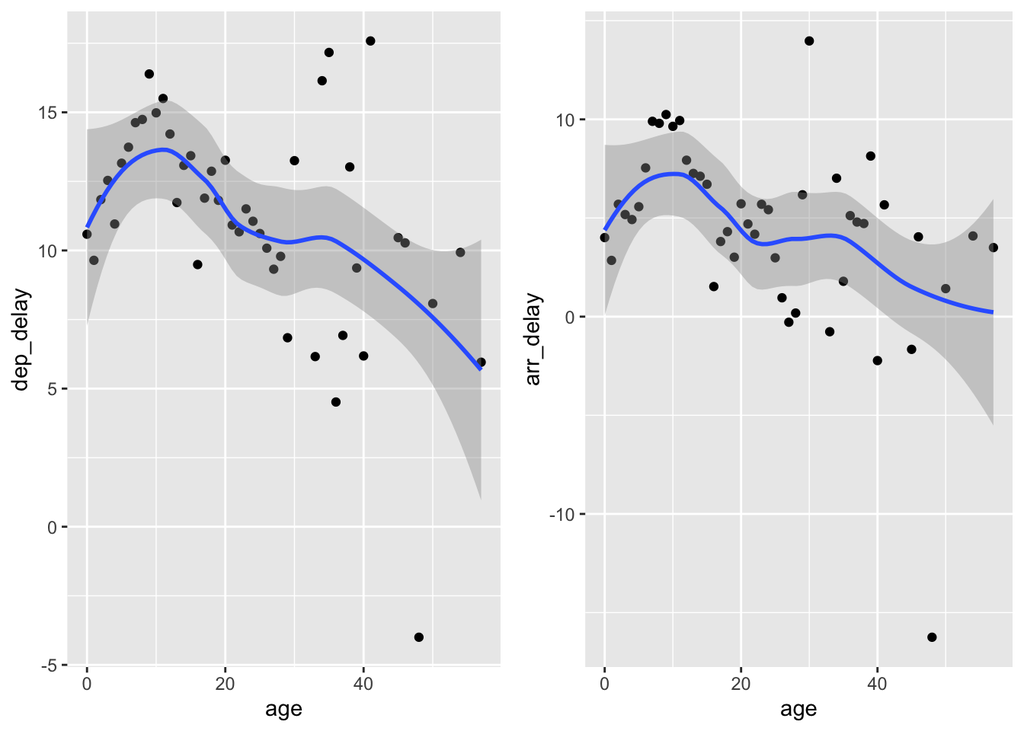

```r
combined_data = inner_join(flights,
  select(planes, tailnum, plane_year = year),
  by = "tailnum") %>%
  mutate(age = year - plane_year) %>%
  group_by(age) %>%
  summarise(
    dep_delay = mean(dep_delay, na.rm = TRUE),
    arr_delay = mean(arr_delay, na.rm = TRUE),
    arr_delay_num = sum(!is.na(arr_delay)),
    dep_delay_num = sum(!is.na(dep_delay))
  )

## relationship between the age of a plane and its delays
plot1 = ggplot(combined_data, aes(x = age, y = dep_delay)) +
  geom_point()+
  geom_smooth()

plot2 = ggplot(combined_data, aes(x = age, y = arr_delay)) +
  geom_point() +
  geom_smooth()

grid.arrange(plot1, plot2, ncol = 2)
```

## 2. Relationship between weather conditions and the delay.

- As the precipitation increases, both the departure and arrival delays increases as well, as the smoothing line increases as the precipitation increases.
- However, it is hard to say that the departure and arrival delays are highly correlated with the precipitation, because there are some outstanding outliers; there are a few planes that has lower mean delays despite the increasing precipitation.

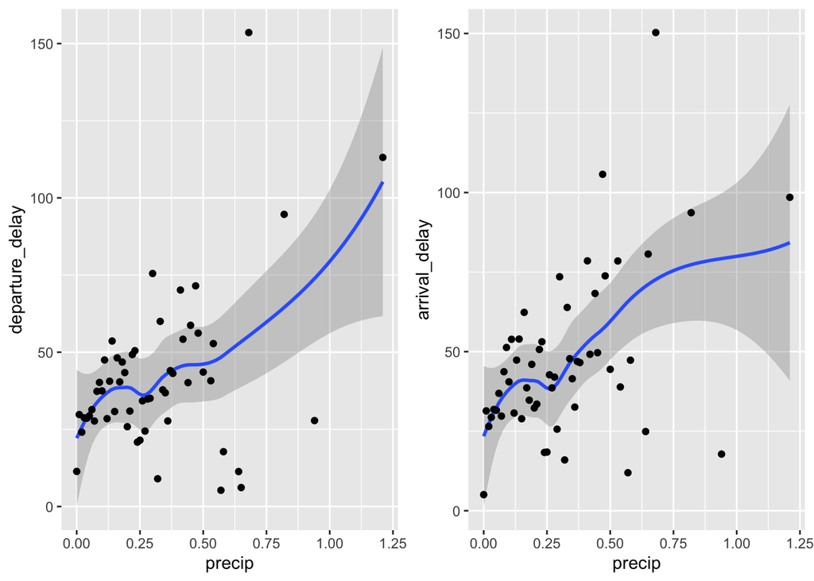

```r
# weather conditions and delay
weather = flights %>%
  inner_join(weather, by = c(
    "origin" = "origin","year" = "year","month" = "month",
    "day" = "day","hour" = "hour"
  ))

plot1 = weather %>%
  group_by(precip) %>%
  summarise(departure_delay = mean(dep_delay, na.rm = TRUE)) %>%
  ggplot(aes(x = precip, y = departure_delay)) +
  geom_smooth() +
  geom_point() #+ geom_line()

plot2 = weather %>%
  group_by(precip) %>%
  summarise(arrival_delay = mean(arr_delay, na.rm = TRUE)) %>%
  ggplot(aes(x = precip, y = arrival_delay)) +
  geom_smooth() + geom_point()

grid.arrange(plot1, plot2, ncol = 2)
```

## 3. Looking for the hours that had the worst delays

```r
most_delays = flights %>%
  mutate(hour = sched_dep_time %/% 100) %>%
  group_by(origin, year, month, day, hour) %>%
  summarise(dep_delay = mean(dep_delay, na.rm = TRUE))  %>%
  ungroup() %>%
  arrange(desc(dep_delay))
```

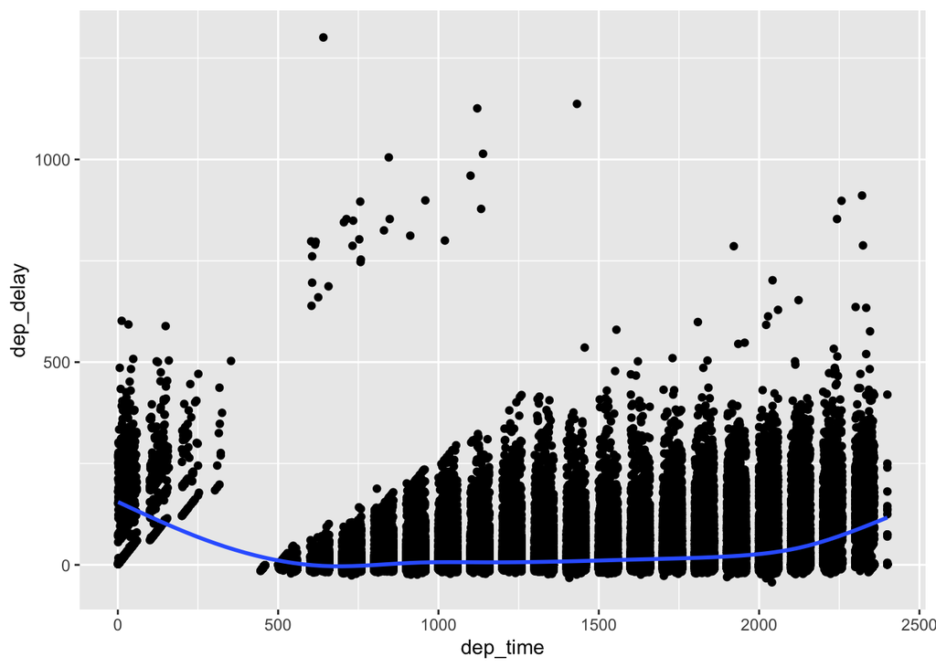

```r
weather_most_delayed <- semi_join(weather, most_delays,
                                  by = c("origin", "year",
                                         "month", "day", "hour"))

ggplot(weather_most_delayed, aes(x = dep_time, y = dep_delay)) + geom_point() + geom_smooth()
```